# WTI Options Portfolio: Full Greek P&L Attribution

Individual Project

Author

Brandon Choi

Published

March 6, 2026

# Description

You are a risk analyst at an energy trading desk. The desk holds a portfolio of WTI crude oil options — specifically, options on NYMEX CL futures contracts.

Your role is to:

- Build a full-Greek P&L attribution framework: the standard tool used on trading desks to explain daily P&L movements across **Delta** (directional exposure), **Gamma** (curvature), **Vega** (volatility sensitivity), **Vanna** (sensitivity of delta to volatility), and **Theta** (time decay).
- You are expected to understand contracts and use the right option model and specifications in the `RTL` package.
- Tell me in your own words the portfolio’s risk profile, how the Greeks interact, and what this means for a desk managing this book in practice.
- No AI use in any shape or form and assignment submitted should be a github repo that I can clone and assess.

# Objective

1. Compute numerical Greeks for each position and for the overall portfolio across the full WTI price range ($50–$100/bbl).
2. Interpret the portfolio’s mark-to-market profile and explain how changing Gamma across strike levels affects delta-hedging in practice.
3. Build a complete P&L attribution framework — Delta, Gamma, Vega, Vanna, and Theta — and verify it accurately explains overnight P&L under a realistic market move.
4. Critically evaluate where and why the linear/quadratic approximation breaks down as spot moves away from current market.

# Exposure

WTI Options Portfolio

Three-way collar: long put spread + short OTM call | F₀ = $73/bbl

| Position | Type | Strike K ($/bbl) | Maturity | Impl. Vol | Contracts |
| --- | --- | --- | --- | --- | --- |
| P1 | Put | 70.00 | 3M | 35.00% | +2,000 long |
| P2 | Put | 55.00 | 3M | 42.00% | -2,000 short |
| P3 | Call | 80.00 | 3M | 30.00% | -2,000 short |

**Market parameters**: current WTI futures price F₀ = **$73.00/bbl**, risk-free rate r = **4.00%** (annualised, continuously compounded).

Select the appropriate pricing model from the `RTL` package for options on WTI crude oil futures. Consider the nature of the underlying contract — a NYMEX CL futures — when choosing the model and setting its cost-of-carry parameter.

# Question 1 (9 points)

For **each position**, compute the following Greeks **numerically** using central differences evaluated at `F_0`:

- **Delta** (∂V/∂F)
- **Gamma** (∂²V/∂F²)
- **Vega** (∂V/∂σ)
- **Theta** (∂V/∂T)

**Step size selection**: For each Greek, choose an appropriate finite-difference step size and explain your reasoning. A good step is small enough that the finite difference accurately approximates the true derivative, but not so small that floating-point subtraction errors dominate. Consider the natural scale of each risk factor (price in $/bbl, vol as a decimal, time in years) and any special considerations for the short-dated options in this portfolio.

**Dollar scaling**: Each raw numerical derivative gives the option price change **per barrel** for a unit move in the risk factor. To express the Greek as a total dollar P&L impact for a position, multiply by `n × mult`, where `n` is the signed contract count (positive = long, negative = short) and `mult = 1,000 bbl/contract`. For example, a delta of 0.50/bbl for a 3,000-contract long position means the desk gains or loses 0.50 × 3,000 × 1,000 = $1,500,000 per $1/bbl move in WTI.

Create plots showing each Greek vs. futures price over F ∈ [50, 100], with one line per position.

**d.** Compute the **portfolio mark-to-market (MTM)** value and **portfolio Gamma** across F ∈ [50, 100]. Plot them on two separate panels. In 3–5 sentences, explain:

- What the MTM profile shape reveals about the portfolio’s net directionality and curvature.
- Where portfolio Gamma is highest and lowest across the price range, and why those regions correspond to specific positions.
- What the changing Gamma means for a delta-hedger rebalancing daily as WTI moves through the $50–$100 range.

```r
# Greeks
S <- F_0
r <- r
N_q1 <- 1000

step.size_q1_DG <- 0.50
step.size_q1_V <- 0.01
step.size_q1_T <- 1 / 365

# Position P1
xp1_q1 <- 70.00
t2mp1_q1 <- 1 / 4
bp1_q1 <- 0
sigmap1_q1 <- 0.35

# Position P1 Delta / Gamma
p1_q1.downDG <- RTL::CRROption(S - step.size_q1_DG, X = xp1_q1, T2M = t2mp1_q1, r, b = bp1_q1, sigma = sigmap1_q1, N = N_q1, type = "put", optionStyle = "american")$price
p1_q1.currentDG <- RTL::CRROption(S, X = xp1_q1, T2M = t2mp1_q1, r, b = bp1_q1, sigma = sigmap1_q1, N = N_q1, type = "put", optionStyle = "american")$price
p1_q1.upDG <-RTL::CRROption(S + step.size_q1_DG, X = xp1_q1, T2M = t2mp1_q1, r, b = bp1_q1, sigma = sigmap1_q1, N = N_q1, type = "put", optionStyle = "american")$price

delta.numericalp1_q1 <- (p1_q1.upDG - p1_q1.downDG) / (2 * step.size_q1_DG)
gamma.numericalp1_q1 <- (p1_q1.upDG - 2 * p1_q1.currentDG +  p1_q1.downDG) / (step.size_q1_DG ^ 2)

# Position P1 Vega
p1_q1.downV <- RTL::CRROption(S, X = xp1_q1, T2M = t2mp1_q1, r, b = bp1_q1, sigma = sigmap1_q1 - step.size_q1_V, N = N_q1, type = "put", optionStyle = "american")$price
p1_q1.currentV <- RTL::CRROption(S, X = xp1_q1, T2M = t2mp1_q1, r, b = bp1_q1, sigma = sigmap1_q1, N = N_q1, type = "put", optionStyle = "american")$price
p1_q1.upV <- RTL::CRROption(S, X = xp1_q1, T2M = t2mp1_q1, r, b = bp1_q1, sigma = sigmap1_q1 + step.size_q1_V, N = N_q1, type = "put", optionStyle = "american")$price

vega.numericalp1_q1 <- (p1_q1.upV - p1_q1.downV) / (2 * step.size_q1_V * 100)

# Position P1 Theta
p1_q1.downT <- RTL::CRROption(S, X = xp1_q1, T2M = t2mp1_q1 - step.size_q1_T, r, b = bp1_q1, sigma = sigmap1_q1, N = N_q1, type = "put", optionStyle = "american")$price
p1_q1.currentT <- RTL::CRROption(S, X = xp1_q1, T2M = t2mp1_q1, r, b = bp1_q1, sigma = sigmap1_q1, N = N_q1, type = "put", optionStyle = "american")$price

theta.numericalp1_q1 <- (p1_q1.downT - p1_q1.currentT)

# Position P2
xp2_q1 <- 55.00
t2mp2_q1 <- 1 / 4
bp2_q1 <- 0
sigmap2_q1 <- 0.42

# Position P2 Delta / Gamma
p2_q1.downDG <- RTL::CRROption(S - step.size_q1_DG, X = xp2_q1, T2M = t2mp2_q1, r, b = bp2_q1, sigma = sigmap2_q1, N = N_q1, type = "put", optionStyle = "american")$price
p2_q1.currentDG <- RTL::CRROption(S, X = xp2_q1, T2M = t2mp2_q1, r, b = bp2_q1, sigma = sigmap2_q1, N = N_q1, type = "put", optionStyle = "american")$price
p2_q1.upDG <-RTL::CRROption(S + step.size_q1_DG, X = xp2_q1, T2M = t2mp2_q1, r, b = bp2_q1, sigma = sigmap2_q1, N = N_q1, type = "put", optionStyle = "american")$price

delta.numericalp2_q1 <- (p2_q1.upDG - p2_q1.downDG) / (2 * step.size_q1_DG)
gamma.numericalp2_q1 <- (p2_q1.upDG - 2 * p2_q1.currentDG +  p2_q1.downDG) / (step.size_q1_DG ^ 2)

# Position P2 Vega
p2_q1.downV <- RTL::CRROption(S, X = xp2_q1, T2M = t2mp2_q1, r, b = bp2_q1, sigma = sigmap2_q1 - step.size_q1_V, N = N_q1, type = "put", optionStyle = "american")$price
p2_q1.currentV <- RTL::CRROption(S, X = xp2_q1, T2M = t2mp2_q1, r, b = bp2_q1, sigma = sigmap2_q1, N = N_q1, type = "put", optionStyle = "american")$price
p2_q1.upV <- RTL::CRROption(S, X = xp2_q1, T2M = t2mp2_q1, r, b = bp2_q1, sigma = sigmap2_q1 + step.size_q1_V, N = N_q1, type = "put", optionStyle = "american")$price

vega.numericalp2_q1 <- (p2_q1.upV - p2_q1.downV) / (2 * step.size_q1_V * 100)

# Position P2 Theta
p2_q1.downT <- RTL::CRROption(S, X = xp2_q1, T2M = t2mp2_q1 - step.size_q1_T, r, b = bp2_q1, sigma = sigmap2_q1, N = N_q1, type = "put", optionStyle = "american")$price
p2_q1.currentT <- RTL::CRROption(S, X = xp2_q1, T2M = t2mp2_q1, r, b = bp2_q1, sigma = sigmap2_q1, N = N_q1, type = "put", optionStyle = "american")$price

theta.numericalp2_q1 <- (p2_q1.downT - p2_q1.currentT)

# Position P3
xp3_q1 <- 80.00
t2mp3_q1 <- 1 / 4
bp3_q1 <- 0
sigmap3_q1 <- 0.3

# Position P3 Delta / Gamma
p3_q1.downDG <- RTL::CRROption(S - step.size_q1_DG, X = xp3_q1, T2M = t2mp3_q1, r, b = bp3_q1, sigma = sigmap3_q1, N = N_q1, type = "call", optionStyle = "american")$price
p3_q1.currentDG <- RTL::CRROption(S, X = xp3_q1, T2M = t2mp3_q1, r, b = bp3_q1, sigma = sigmap3_q1, N = N_q1, type = "call", optionStyle = "american")$price
p3_q1.upDG <-RTL::CRROption(S + step.size_q1_DG, X = xp3_q1, T2M = t2mp3_q1, r, b = bp3_q1, sigma = sigmap3_q1, N = N_q1, type = "call", optionStyle = "american")$price

delta.numericalp3_q1 <- (p3_q1.upDG - p3_q1.downDG) / (2 * step.size_q1_DG)
gamma.numericalp3_q1 <- (p3_q1.upDG - 2 * p3_q1.currentDG +  p3_q1.downDG) / (step.size_q1_DG ^ 2)

# Position P3 Vega
p3_q1.downV <- RTL::CRROption(S, X = xp3_q1, T2M = t2mp3_q1, r, b = bp3_q1, sigma = sigmap3_q1 - step.size_q1_V, N = N_q1, type = "call", optionStyle = "american")$price
p3_q1.currentV <- RTL::CRROption(S, X = xp3_q1, T2M = t2mp3_q1, r, b = bp3_q1, sigma = sigmap3_q1, N = N_q1, type = "call", optionStyle = "american")$price
p3_q1.upV <- RTL::CRROption(S, X = xp3_q1, T2M = t2mp3_q1, r, b = bp3_q1, sigma = sigmap3_q1 + step.size_q1_V, N = N_q1, type = "call", optionStyle = "american")$price

vega.numericalp3_q1 <- (p3_q1.upV - p3_q1.downV) / (2 * step.size_q1_V * 100)

# Position P3 Theta
p3_q1.downT <- RTL::CRROption(S, X = xp3_q1, T2M = t2mp3_q1 - step.size_q1_T, r, b = bp3_q1, sigma = sigmap3_q1, N = N_q1, type = "call", optionStyle = "american")$price
p3_q1.currentT <- RTL::CRROption(S, X = xp3_q1, T2M = t2mp3_q1, r, b = bp3_q1, sigma = sigmap3_q1, N = N_q1, type = "call", optionStyle = "american")$price

theta.numericalp3_q1 <- (p3_q1.downT - p3_q1.currentT)

greeks_table <- dplyr::tribble(
  ~Greeks, ~P1, ~P2, ~P3,
  "Delta", delta.numericalp1_q1, delta.numericalp2_q1, delta.numericalp3_q1,
  "Gamma", gamma.numericalp1_q1, gamma.numericalp2_q1, gamma.numericalp3_q1,
  "Vega", vega.numericalp1_q1, vega.numericalp2_q1, vega.numericalp3_q1,
  "Theta", theta.numericalp1_q1, theta.numericalp2_q1, theta.numericalp3_q1
) %>%
  gt::gt() %>%
  gt::tab_header(
    title    = "Greeks",
    subtitle = "") %>%
    gt::fmt_number(columns = c(P1, P2, P3), decimals = 2)
```

# Step Size Selection

For Delta, I chose 0.5 as the step size. While the minimum price fluctuation / barrel was listed at 0.01 on the CME, I believed that this would be too small of a step size. While the WTI contract on the CME (open - close) / 2 of ~ $0.75, I believed that with the shorter expiry, a smaller denomination would work best.

For Gamma, I also chose 0.5 as the step rate for the same reasons. Both of these greeks are related to the price of the contract. Since shorter step sizes can more accurately model lower T2M’s, this works well for our contracts.

For Vega, I chose 0.01 as the step size as that would be the smallest measure of change in implied volatility.

For Theta, I choose a step size of 1 / 365. This is because the Maturity was given as 3M, and I believed that value would already have been annualized. Since shorter step sizes can more accurately model lower T2M’s, this works well for our contracts.

```r
### Dollar Scaling
dollar_deltap1_q1 <- delta.numericalp1_q1 * (2000 * mult)
dollar_gammap1_q1 <- gamma.numericalp1_q1 * (2000 * mult)
dollar_vegap1_q1 <- vega.numericalp1_q1 * (2000 * mult)
dollar_thetap1_q1 <- theta.numericalp1_q1 * (2000 * mult)

dollar_deltap2_q1 <- delta.numericalp2_q1 * (-2000 * mult)
dollar_gammap2_q1 <- gamma.numericalp2_q1 * (-2000 * mult)
dollar_vegap2_q1 <- vega.numericalp2_q1 * (-2000 * mult)
dollar_thetap2_q1 <- theta.numericalp2_q1 * (-2000 * mult)

dollar_deltap3_q1 <- delta.numericalp3_q1 * (-2000 * mult)
dollar_gammap3_q1 <- gamma.numericalp3_q1 * (-2000 * mult)
dollar_vegap3_q1 <- vega.numericalp3_q1 * (-2000 * mult)
dollar_thetap3_q1 <- theta.numericalp3_q1 * (-2000 * mult)

dollar_delta_total_q1 <- dollar_deltap1_q1 + dollar_deltap2_q1 + dollar_deltap3_q1
dollar_gamma_total_q1 <- dollar_gammap1_q1 + dollar_gammap2_q1 + dollar_gammap3_q1
dollar_vega_total_q1 <- dollar_vegap1_q1 + dollar_vegap2_q1 + dollar_vegap3_q1
dollar_theta_total_q1 <- dollar_thetap1_q1 + dollar_thetap2_q1 + dollar_thetap3_q1

dollar_greeks_table <- dplyr::tribble(
  ~Greeks, ~P1, ~P2, ~P3,
  "Delta", dollar_deltap1_q1, dollar_deltap2_q1, dollar_deltap3_q1,
  "Gamma", dollar_gammap1_q1, dollar_gammap2_q1, dollar_gammap3_q1,
  "Vega", dollar_vegap1_q1, dollar_vegap2_q1, dollar_vegap3_q1,
  "Theta", dollar_thetap1_q1, dollar_thetap2_q1, dollar_thetap3_q1
) %>%
  gt::gt() %>%
  gt::tab_header(
    title    = "Dollar Scaled Greeks",
    subtitle = "$ Pnl / $1/bbl movement") %>%
    gt::fmt_number(columns = c(P1, P2, P3), decimals = 2)
```

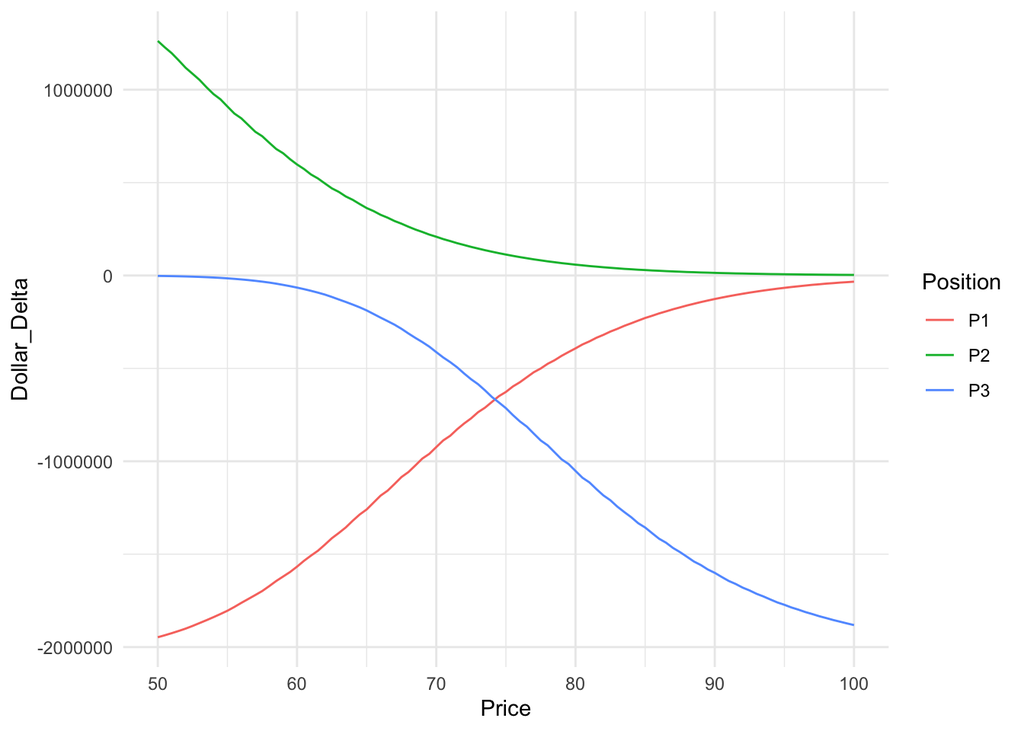

```r
f_range_q1 <- seq(50, 100, 0.5)

### Delta Data
delta_data_p1 <- tibble(Price = f_range_q1) %>%
  dplyr::mutate(P1 = purrr::map_dbl(Price, function(S) {
down <- RTL::CRROption(S - step.size_q1_DG, X = xp1_q1, T2M = t2mp1_q1, r, b = bp1_q1, sigma = sigmap1_q1, N = N_q1, type = "put", optionStyle = "american")$price
current <- RTL::CRROption(S, X = xp1_q1, T2M = t2mp1_q1, r, b = bp1_q1, sigma = sigmap1_q1, N = N_q1, type = "put", optionStyle = "american")$price
up <-RTL::CRROption(S + step.size_q1_DG, X = xp1_q1, T2M = t2mp1_q1, r, b = bp1_q1, sigma = sigmap1_q1, N = N_q1, type = "put", optionStyle = "american")$price
(up - down) / (2 * step.size_q1_DG)
}) * 2000 * mult
)

delta_data_p2 <- tibble(Price = f_range_q1) %>%
  dplyr::mutate(P2 = purrr::map_dbl(Price, function(S) {
down <- RTL::CRROption(S - step.size_q1_DG, X = xp2_q1, T2M = t2mp2_q1, r, b = bp2_q1, sigma = sigmap2_q1, N = N_q1, type = "put", optionStyle = "american")$price
current <- RTL::CRROption(S, X = xp2_q1, T2M = t2mp2_q1, r, b = bp2_q1, sigma = sigmap2_q1, N = N_q1, type = "put", optionStyle = "american")$price
up <-RTL::CRROption(S + step.size_q1_DG, X = xp2_q1, T2M = t2mp2_q1, r, b = bp2_q1, sigma = sigmap2_q1, N = N_q1, type = "put", optionStyle = "american")$price
(up - down) / (2 * step.size_q1_DG)
}) * -2000 * mult
)

delta_data_p3 <- tibble(Price = f_range_q1) %>%
  dplyr::mutate(P3 = purrr::map_dbl(Price, function(S) {
down <- RTL::CRROption(S - step.size_q1_DG, X = xp3_q1, T2M = t2mp3_q1, r, b = bp3_q1, sigma = sigmap3_q1, N = N_q1, type = "call", optionStyle = "american")$price
current <- RTL::CRROption(S, X = xp3_q1, T2M = t2mp3_q1, r, b = bp3_q1, sigma = sigmap3_q1, N = N_q1, type = "call", optionStyle = "american")$price
up <-RTL::CRROption(S + step.size_q1_DG, X = xp3_q1, T2M = t2mp3_q1, r, b = bp3_q1, sigma = sigmap3_q1, N = N_q1, type = "call", optionStyle = "american")$price
(up - down) / (2 * step.size_q1_DG)
}) * -2000 * mult
)

delta_plot <- delta_data_p1 %>%
  left_join(delta_data_p2, by = "Price") %>%
  left_join(delta_data_p3, by = "Price") %>%
  pivot_longer(cols = c(P1, P2, P3), names_to = "Position", values_to = "Dollar_Delta") %>%
  ggplot(aes(x = Price, y = Dollar_Delta, color = Position)) +
  geom_line() +
  theme_minimal()





### Gamma Data
gamma_data_p1 <- tibble(Price = f_range_q1) %>%
  dplyr::mutate(P1 = purrr::map_dbl(Price, function(S) {
down <- RTL::CRROption(S - step.size_q1_DG, X = xp1_q1, T2M = t2mp1_q1, r, b = bp1_q1, sigma = sigmap1_q1, N = N_q1, type = "put", optionStyle = "american")$price
current <- RTL::CRROption(S, X = xp1_q1, T2M = t2mp1_q1, r, b = bp1_q1, sigma = sigmap1_q1, N = N_q1, type = "put", optionStyle = "american")$price
up <-RTL::CRROption(S + step.size_q1_DG, X = xp1_q1, T2M = t2mp1_q1, r, b = bp1_q1, sigma = sigmap1_q1, N = N_q1, type = "put", optionStyle = "american")$price
(up - 2 * current + down) / (step.size_q1_DG ^ 2)
}) * 2000 * mult
)

gamma_data_p2 <- tibble(Price = f_range_q1) %>%
  dplyr::mutate(P2 = purrr::map_dbl(Price, function(S) {
down <- RTL::CRROption(S - step.size_q1_DG, X = xp2_q1, T2M = t2mp2_q1, r, b = bp2_q1, sigma = sigmap2_q1, N = N_q1, type = "put", optionStyle = "american")$price
current <- RTL::CRROption(S, X = xp2_q1, T2M = t2mp2_q1, r, b = bp2_q1, sigma = sigmap2_q1, N = N_q1, type = "put", optionStyle = "american")$price
up <-RTL::CRROption(S + step.size_q1_DG, X = xp2_q1, T2M = t2mp2_q1, r, b = bp2_q1, sigma = sigmap2_q1, N = N_q1, type = "put", optionStyle = "american")$price
(up - 2 * current + down) / (step.size_q1_DG ^ 2)
}) * -2000 * mult
)

gamma_data_p3 <- tibble(Price = f_range_q1) %>%
  dplyr::mutate(P3 = purrr::map_dbl(Price, function(S) {
down <- RTL::CRROption(S - step.size_q1_DG, X = xp3_q1, T2M = t2mp3_q1, r, b = bp3_q1, sigma = sigmap3_q1, N = N_q1, type = "call", optionStyle = "american")$price
current <- RTL::CRROption(S, X = xp3_q1, T2M = t2mp3_q1, r, b = bp3_q1, sigma = sigmap3_q1, N = N_q1, type = "call", optionStyle = "american")$price
up <-RTL::CRROption(S + step.size_q1_DG, X = xp3_q1, T2M = t2mp3_q1, r, b = bp3_q1, sigma = sigmap3_q1, N = N_q1, type = "call", optionStyle = "american")$price
(up - 2 * current + down) / (step.size_q1_DG ^ 2)
}) * -2000 * mult
)

gamma_plot <- gamma_data_p1 %>%
  left_join(gamma_data_p2, by = "Price") %>%
  left_join(gamma_data_p3, by = "Price") %>%
  pivot_longer(cols = c(P1, P2, P3), names_to = "Position", values_to = "Dollar_Gamma") %>%
  ggplot(aes(x = Price, y = Dollar_Gamma, color = Position)) +
  geom_line() +
  theme_minimal()





### Vega Data
vega_data_p1 <- tibble(Price = f_range_q1) %>%
  dplyr::mutate(P1 = purrr::map_dbl(Price, function(S) {
down <- RTL::CRROption(S, X = xp1_q1, T2M = t2mp1_q1, r, b = bp1_q1, sigma = sigmap1_q1 - step.size_q1_V, N = N_q1, type = "put", optionStyle = "american")$price
current <- RTL::CRROption(S, X = xp1_q1, T2M = t2mp1_q1, r, b = bp1_q1, sigma = sigmap1_q1, N = N_q1, type = "put", optionStyle = "american")$price
up <-RTL::CRROption(S, X = xp1_q1, T2M = t2mp1_q1, r, b = bp1_q1, sigma = sigmap1_q1 + step.size_q1_V, N = N_q1, type = "put", optionStyle = "american")$price
(up - down) / (2 * step.size_q1_V * 100)
}) * 2000 * mult
)

vega_data_p2 <- tibble(Price = f_range_q1) %>%
  dplyr::mutate(P2 = purrr::map_dbl(Price, function(S) {
down <- RTL::CRROption(S, X = xp2_q1, T2M = t2mp2_q1, r, b = bp2_q1, sigma = sigmap2_q1 - step.size_q1_V, N = N_q1, type = "put", optionStyle = "american")$price
current <- RTL::CRROption(S, X = xp2_q1, T2M = t2mp2_q1, r, b = bp2_q1, sigma = sigmap2_q1, N = N_q1, type = "put", optionStyle = "american")$price
up <-RTL::CRROption(S, X = xp2_q1, T2M = t2mp2_q1, r, b = bp2_q1, sigma = sigmap2_q1 + step.size_q1_V, N = N_q1, type = "put", optionStyle = "american")$price
(up - down) / (2 * step.size_q1_V * 100)
}) * -2000 * mult
)

vega_data_p3 <- tibble(Price = f_range_q1) %>%
  dplyr::mutate(P3 = purrr::map_dbl(Price, function(S) {
down <- RTL::CRROption(S, X = xp3_q1, T2M = t2mp3_q1, r, b = bp3_q1, sigma = sigmap3_q1 - step.size_q1_V, N = N_q1, type = "call", optionStyle = "american")$price
current <- RTL::CRROption(S, X = xp3_q1, T2M = t2mp3_q1, r, b = bp3_q1, sigma = sigmap3_q1, N = N_q1, type = "call", optionStyle = "american")$price
up <-RTL::CRROption(S, X = xp3_q1, T2M = t2mp3_q1, r, b = bp3_q1, sigma = sigmap3_q1 + step.size_q1_V, N = N_q1, type = "call", optionStyle = "american")$price
(up - down) / (2 * step.size_q1_V * 100)
}) * -2000 * mult
)

vega_plot <- vega_data_p1 %>%
  left_join(vega_data_p2, by = "Price") %>%
  left_join(vega_data_p3, by = "Price") %>%
  pivot_longer(cols = c(P1, P2, P3), names_to = "Position", values_to = "Dollar_Vega") %>%
  ggplot(aes(x = Price, y = Dollar_Vega, color = Position)) +
  geom_line() +
  theme_minimal()






### Theta Data
theta_data_p1 <- tibble(Price = f_range_q1) %>%
  dplyr::mutate(P1 = purrr::map_dbl(Price, function(S) {
down <- RTL::CRROption(S, X = xp1_q1, T2M = t2mp1_q1 - step.size_q1_T, r, b = bp1_q1, sigma = sigmap1_q1, N = N_q1, type = "put", optionStyle = "american")$price
current <- RTL::CRROption(S, X = xp1_q1, T2M = t2mp1_q1, r, b = bp1_q1, sigma = sigmap1_q1, N = N_q1, type = "put", optionStyle = "american")$price
(down - current)
}) * 2000 * mult
)

theta_data_p2 <- tibble(Price = f_range_q1) %>%
  dplyr::mutate(P2 = purrr::map_dbl(Price, function(S) {
down <- RTL::CRROption(S, X = xp2_q1, T2M = t2mp2_q1 - step.size_q1_T, r, b = bp2_q1, sigma = sigmap2_q1, N = N_q1, type = "put", optionStyle = "american")$price
current <- RTL::CRROption(S, X = xp2_q1, T2M = t2mp2_q1, r, b = bp2_q1, sigma = sigmap2_q1, N = N_q1, type = "put", optionStyle = "american")$price
(down - current)
}) * -2000 * mult
)

theta_data_p3 <- tibble(Price = f_range_q1) %>%
  dplyr::mutate(P3 = purrr::map_dbl(Price, function(S) {
down <- RTL::CRROption(S, X = xp3_q1, T2M = t2mp3_q1 - step.size_q1_T, r, b = bp3_q1, sigma = sigmap3_q1, N = N_q1, type = "call", optionStyle = "american")$price
current <- RTL::CRROption(S, X = xp3_q1, T2M = t2mp3_q1, r, b = bp3_q1, sigma = sigmap3_q1, N = N_q1, type = "call", optionStyle = "american")$price
(down - current)
}) * -2000 * mult
)

theta_plot <- theta_data_p1 %>%
  left_join(theta_data_p2, by = "Price") %>%
  left_join(theta_data_p3, by = "Price") %>%
  pivot_longer(cols = c(P1, P2, P3), names_to = "Position", values_to = "Dollar_Theta") %>%
  ggplot(aes(x = Price, y = Dollar_Theta, color = Position)) +
  geom_line() +
  theme_minimal()

delta_plot
```

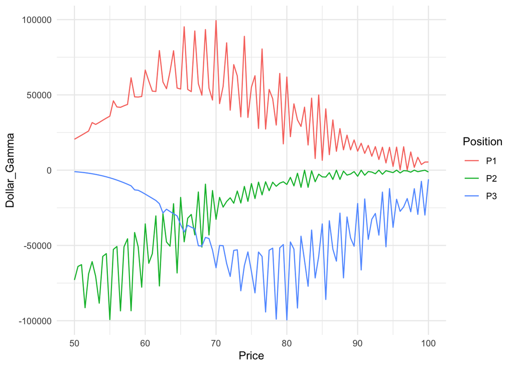

```r
gamma_plot
```

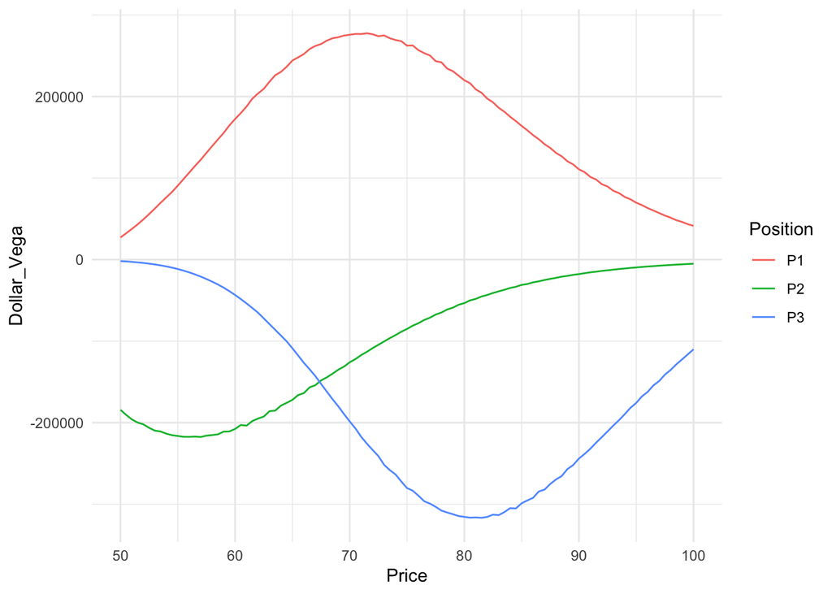

```r
vega_plot
```

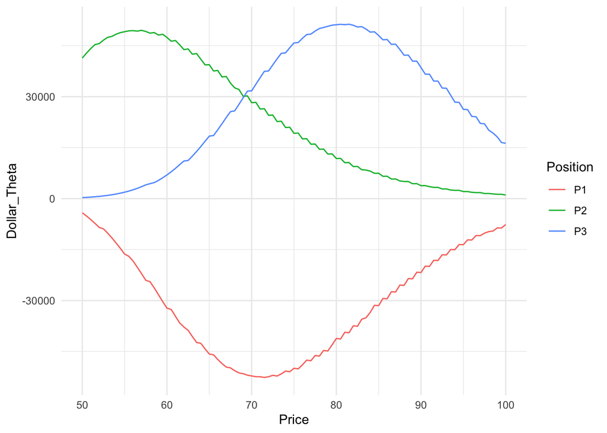

```r
theta_plot
```

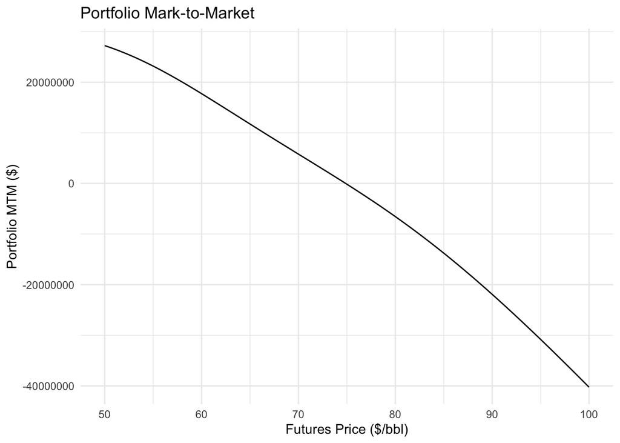

```r
# Question 4
price_CRROption <- function (S, X, T2M, r, b, sigma, type, N, optionStyle) {
  CRROption(S, X, T2M, r, b, sigma, N = N_q1, type, optionStyle = "american")$price
}

mtm_data <- dplyr::tibble(Price = f_range_q1) %>%
  dplyr::mutate(
    P1 = purrr::map_dbl(Price, ~price_CRROption(.x, X = xp1_q1, T2M = t2mp1_q1, r = r, b = bp1_q1, sigma = sigmap1_q1, type = "put")) * 2000 * mult,
    P2 = purrr::map_dbl(Price, ~price_CRROption(.x, X = xp2_q1, T2M = t2mp2_q1, r = r, b = bp2_q1, sigma = sigmap2_q1, type = "put")) * -2000 * mult,
    P3 = purrr::map_dbl(Price, ~price_CRROption(.x, X = xp3_q1, T2M = t2mp3_q1, r = r, b = bp3_q1, sigma = sigmap3_q1, type = "call")) * -2000 * mult,
    Portfolio = P1 + P2 + P3
    )

gamma_data <- gamma_data_p1 %>%
  left_join(gamma_data_p2, by = "Price") %>%
  left_join(gamma_data_p3, by = "Price") %>%
  mutate(Portfolio = P1 + P2 + P3)

mtm_plot <- mtm_data %>%
  ggplot(aes(x = Price, y = Portfolio)) +
  geom_line() +
  labs(x = "Futures Price ($/bbl)", y = "Portfolio MTM ($)", title = "Portfolio Mark-to-Market") +
  theme_minimal()

portfolio_gamma_plot <- gamma_data %>%
  ggplot(aes(x = Price, y = Portfolio)) +
  geom_line() +
  labs(x = "Futures Price ($/bbl)", y = "Portfolio Dollar Gamma ($)", title = "Portfolio Gamma") +
  theme_minimal()

mtm_plot
```

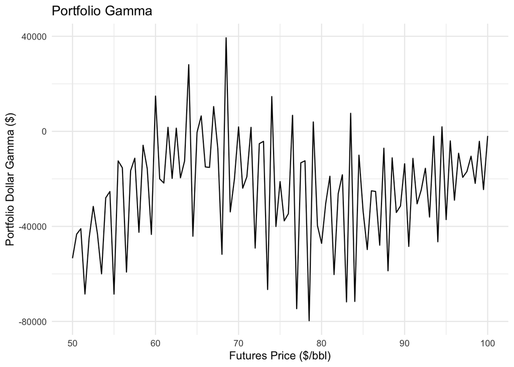

```r
portfolio_gamma_plot
```

For the analysis of Gamma for our portfolio, the highest dollar scaled Gamma region is ~ 68 Dollars and the lowest dollar scaled Gamma region is ~ 78 Dollars. This is because of our long put position near the $70 mark, and our short call position near the 80 Dollar mark. With our additional short put position at 55 Dollars, these peaks are shifted slightly to the left. Gamma is closest to zero near 100 Dollars as that would be the furthest distance away from these options positions.

# Question 2 (3 points)

Sum Greeks across positions to show **portfolio-level Greeks** at the current market. Present in a `gt::gt()` table. At approximately what futures price does the portfolio delta change sign?

```r
portfolio_greeks_table <- dplyr::tibble(
  Greeks = c("Delta", "Gamma", "Vega", "Theta"),
  Portfolio = c(dollar_delta_total_q1, dollar_gamma_total_q1, dollar_vega_total_q1, dollar_theta_total_q1)
) %>%
  gt::gt() %>%
  gt::tab_header(
    title    = "Portfolio Level Greeks",
    subtitle = "Dollar Scaled") %>%
    gt::fmt_number(columns = c("Portfolio"), decimals = 2)

delta_data <- delta_data_p1 %>%
  left_join(delta_data_p2, by = "Price") %>%
  left_join(delta_data_p3, by = "Price") %>%
  mutate(Portfolio = P1 + P2 + P3)

delta_positive <- delta_data %>%
  filter(Portfolio > 0)
```

# Question 3 (8 points)

Overnight, US-Iran tensions escalate sharply. The US strikes Iranian nuclear facilities; Iran retaliates by mining the Strait of Hormuz. WTI gaps up at the open:

- WTI futures: F moves from **73.00** to **90.00** (+$17.00/bbl)
- Implied volatility: each position’s sigma spikes by **+0.20** (20 vol points)
- Time: **1 calendar day** passes

For each position and for the portfolio total, compute:

1. **Actual P&L**: full revaluation at new F, new sigma, new T. P&L = (new price − old price) × n × mult.
2. **Attributed P&L**: ΔV ≈ (Delta × ΔF) + (½ × Gamma × ΔF²) + (Vega × Δσ) + (Vanna × ΔF × Δσ) + (Theta × Δt), scaled to dollars.
3. **Unexplained residual**: Actual − Attributed.
4. **Attribution breakdown**: what share (%) of Attributed P&L comes from each Greek?

**Vanna** (∂²V/∂F∂σ) measures how delta changes as volatility moves. With both a large spot jump and a large vol spike coinciding, Vanna is non-negligible. Use a central-difference cross-partial:

$$\text{Vanna} = \frac{V(F+h, \sigma+k) - V(F+h, \sigma-k) - V(F-h, \sigma+k) + V(F-h, \sigma-k)}{4 \cdot h \cdot k}$$

with h = `step_S` and k = `step_v`. The Vanna P&L contribution is Vanna × ΔF × Δσ.

Present all results in a `gt::gt()` table. Which position dominates the loss? Is the Greek attribution a reliable approximation here, and why or why not?

```r
S_q3 <- 90
r <- r
N_q3 <- 1000

step.size_q3_DG <- 0.50
step.size_q3_V <- 0.01
step.size_q3_T <- 1 / 365

sigma_p1_q3 <- 0.55
sigma_p2_q3 <- 0.62
sigma_p3_q3 <- 0.62
t2m_q3 <- (1 / 4) - (1 / 365)

old_p1 <- RTL::CRROption(S, X = xp1_q1, T2M = t2mp1_q1, r, b = 0, sigma = sigmap1_q1, N = N_q1, type = "put", optionStyle = "american")$price
old_p2 <- RTL::CRROption(S, X = xp2_q1, T2M = t2mp2_q1, r, b = 0, sigma = sigmap2_q1, N = N_q1, type = "put", optionStyle = "american")$price
old_p3 <- RTL::CRROption(S, X = xp3_q1, T2M = t2mp3_q1, r, b = 0, sigma = sigmap3_q1, N = N_q1, type = "call", optionStyle = "american")$price

shock_p1 <- RTL::CRROption(S_q3 - step.size_q1_DG, X = xp1_q1, T2M = t2m_q3, r, b = bp1_q1, sigma = sigma_p1_q3, N = N_q1, type = "put", optionStyle = "american")$price
shock_p2 <- RTL::CRROption(S_q3 - step.size_q1_DG, X = xp1_q1, T2M = t2m_q3, r, b = bp1_q1, sigma = sigma_p2_q3, N = N_q1, type = "put", optionStyle = "american")$price
shock_p3 <- RTL::CRROption(S_q3 - step.size_q1_DG, X = xp1_q1, T2M = t2m_q3, r, b = bp1_q1, sigma = sigma_p3_q3, N = N_q1, type = "call", optionStyle = "american")$price

pnl_p1 <- (shock_p1 - old_p1) * 2000 * mult
pnl_p2 <- (shock_p2 - old_p2) * -2000 * mult
pnl_p3 <- (shock_p3 - old_p3) * -2000 * mult

actual_pnl <- pnl_p1 + pnl_p2 + pnl_p3
```

# Question 4 (4 points)

The Iran war scenario (ΔF = +$17) is an extreme move. How well does the Greek approximation hold as WTI moves further from the current market?

Holding vol and time constant at their initial values, compute Actual P&L (full revaluation) and Attributed P&L (Delta + Gamma only) for the portfolio across ΔF ∈ [–20, +20] in $1 increments.

**a.** Plot Actual, Attributed, and the Residual on the same chart. Mark the Iran war move (ΔF = +17) with a vertical line.

**b.** At what ΔF does the absolute residual first exceed 5% of the absolute Actual P&L? Report in a `gt::gt()` table. What does this tell you about using Greeks for risk management in extreme scenarios?

# Question 5 (6 points)

Discuss the key learnings and insights from a Greek risk management perspective. Your explanation must:

- Interpret the **full revaluation MTM profile** from Q1(d): describe the portfolio’s curvature structure across the $50–$100 range. Identify the regions of maximum and minimum Gamma. Explain what the changing Gamma means for a desk running this portfolio — specifically, how frequently delta rebalancing is needed as WTI moves through the strikes.
- Interpret the **full revaluation P&L and Gamma profiles** from Q1(d): describe the portfolio’s curvature structure and identify which positions drive positive vs negative Gamma regions.
- Identify which position and which Greek drove the largest loss in the Iran war scenario, and explain why that was predictable from the portfolio structure.
- Explain the role of **Vanna**: why is it non-trivial when both a large spot jump and a large vol spike occur simultaneously?
- Explain why the Greek approximation (Q4) breaks down at extreme moves, and what this means for a real desk managing this book.

Pay particular attention to why textbook delta-hedging assumptions break down in geopolitical gap scenarios, and what risk tools a real energy desk would use instead.